# `morphogram`

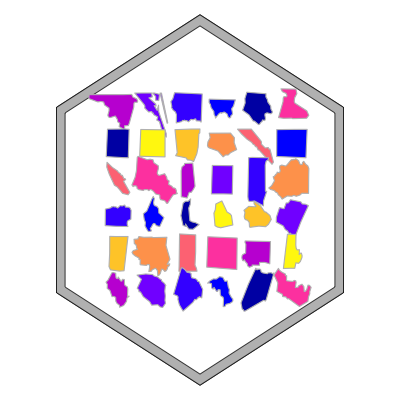

[figure not shown]

- Version: 0.3.0 (beta).
- Author: Toby C. Wilkinson.
- Date of this README document: 2019-08-02.

This R-package is designed to facilitate the construction of “morphogram”-based infographics which place dispersed spatial features side-by-side, for example *to compare visually the shapes or dimensions of cities, study regions or building sizes in two dimensional space*. The package aims to preserve recognisable or accurate **shapes** (and by default, the linear **dimensions**) of the features to allow human recognition, but transpose their spatial *position* so that they are distributed in a visually understandable way. When spatial *dimensions* are preserved, further spatial analysis (e.g. area calculations) or the additional of scale bars can be accurately plotted.

Functions rely on `sf` objects as inputs and outputs, hence the primary dependency of this package is `sf`. The use of `sf` objects provides maximum flexibility for ultimate graphics output; users can use base graphics or alternatives such as `ggplot` according to need or preference with the resulting reprojected and translated `sf` features.

Although theoretically any `sf`-compatible spatial features can be processed with this package, the most likely application is the orientation of polygons in a way that their relative size can be easily compared.

The original design use-case was archaeological, namely the visualization of the relative size of study regions of different archaeological surveys, ancient theatre plans and the relative size of ancient cities.

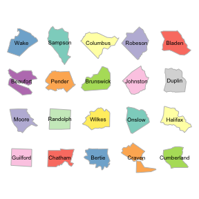

## Installation

This package relies on the `sf` package for calculating geometries and handling spatial data. Depending on the platform you are using, you may need to install GDAL and other dependencies before using `sf` and `morphogram`. Read the `sf` documentation for more information: [see sf README on GitHub](https://github.com/r-spatial/sf/).

You can install the current development version of `morphogram` from [GitHub](https://github.com/) with:

```r
# install.packages("devtools")
devtools::install_github("tcwilkinson/morphogram")
```

## Basic Example

- Aligning, distributing and plotting North Carolina districts as a grid

This example shows you how to converge, distribute and then plot a set of simple (spatial) features using data distributed with the `sf` package:

```r
library(sf)
library(morphogram)
```

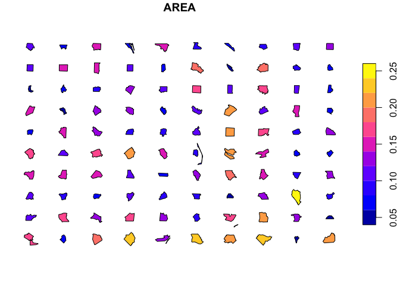

```r
# load polygon data from the sf package
nc <- sf::st_read(system.file("shape/nc.shp", package="sf"),quiet=T)
# converge polygons around origin
nc_converged <- converge(nc,by.feature=T)
# distribute polygons into regular grid
nc_distributed <- distribute(nc_converged, margin=1, x.mar=2)
# plot resulting distributed features
# optional: select first parameter, this is just for clarity of the final plot
nc_d <- nc_distributed[1] # AREA
plot(nc_d)
```

**For more information on how to get started, read the introduction vignette for guidance on how to get started using this package**:

```r
browseVignettes("morphogram")
```

Or browse the documentation and vignette online: https://tcwilkinson.github.io/morphogram/

## Applications

- City size comparison
- Study region comparison

Do let me know if you use this package in any publications, I’d be pleased to link to them here.

## Improvements and Contributions

For ideas and plans on how to improve this package in the future, see the TODO.md file.

Pull requests on this package which improve the documentation and methods are welcome.